# Analytics Lab Project with Disruptive Elements GmbH: Network Twitter Analysis in R

Anna Anisienia

30 June 2018

## How often people google Bitcoin and Ethereum?

In the plot below (*and by sorting the table by hits in descending order*), we can see that the number of hits in Google Trends reached a peak during and after the Bitcoin Crash in June 2018.

```r
library(gtrendsR)
library(ggplot2)
library(dplyr)
library(lubridate)
library(DT)
Sys.setenv(TZ="Europe/Berlin") # to be sure: time series analysis
KEYWORDS <- c("Bitcoin", "Ethereum")
gTrendsData <- gtrends(keyword = KEYWORDS, time = paste("2018-06-01", Sys.Date()), geo = "DE") # BTC crash 8-10.06.2018
datTS <- gTrendsData$interest_over_time[, c("date", "hits", "keyword")]
# Create variables for weekdays and weekends
datTS$weekday <- lubridate::wday(datTS$date, label = TRUE, week_start = 1)
datTS$weekend <- datTS$weekday %in% c("Sat", "Sun")
datatable(datTS)
```

|  | date | hits | keyword | weekday | weekend |
| --- | --- | --- | --- | --- | --- |
| 1 | 2018-05-31T22:00:00Z | 59 | Bitcoin | Fri | False |
| 2 | 2018-06-01T22:00:00Z | 54 | Bitcoin | Sat | True |
| 3 | 2018-06-02T22:00:00Z | 59 | Bitcoin | Sun | True |
| 4 | 2018-06-03T22:00:00Z | 59 | Bitcoin | Mon | False |
| 5 | 2018-06-04T22:00:00Z | 61 | Bitcoin | Tue | False |
| 6 | 2018-06-05T22:00:00Z | 61 | Bitcoin | Wed | False |
| 7 | 2018-06-06T22:00:00Z | 53 | Bitcoin | Thu | False |
| 8 | 2018-06-07T22:00:00Z | 55 | Bitcoin | Fri | False |
| 9 | 2018-06-08T22:00:00Z | 52 | Bitcoin | Sat | True |
| 10 | 2018-06-09T22:00:00Z | 82 | Bitcoin | Sun | True |

[output cut: 46 more lines]

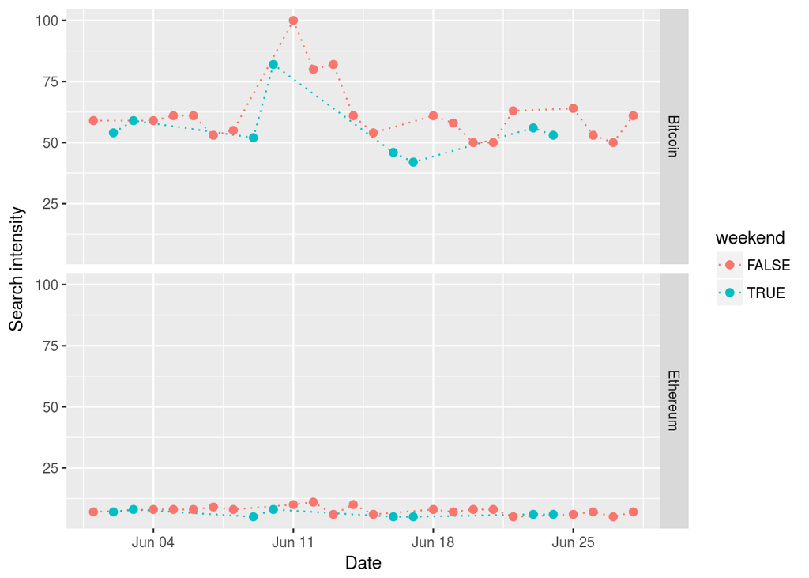

```r
ggplot(datTS, aes(x = date, y = hits, color = weekend)) +
    geom_line(linetype = 3) + ## 0 = blank, 1 = solid, 2 = dashed, 3 = dotted, # 4 = dotdash, 5 = longdash, 6 = twodash; default SOLID
    geom_point(size = 2) +
    facet_grid(keyword ~ .) +
    labs(x = "Date", y = "Search intensity")
```

## Preprocessing for Network Analysis

### Postgres

The data has been obtained through streaming from Twitter API by using Python Tweepy library and self-implemented StreamListener that constantly appends new streamed data into a Postgres Database `disruptive` created on the Zeno server: `zeno.lehre.hwr-berlin.de`. Details about streaming are provided in a separate documentation. - for retrieval of the data from Postgres database, we use `RPostgreSQL` library and SQL queries that filter for only relevant tweets related to Bitcoin and Ethereum.

```r
library("RPostgreSQL")
drv <- dbDriver("PostgreSQL")
con <- dbConnect(drv, dbname = "disruptive",
                host = "zeno.lehre.hwr-berlin.de", port = 5432,
                user = "consultant", password = "pgHWR2018")
dbExistsTable(con, "twitter3") # check for the table
```

```
## [1] TRUE
```

```r
twitter <- dbGetQuery(con, "select distinct text, tweet_created, influencer, influencer_quoted, user_name, retweeter_requoter  from twitter3
where text ~* '(btc|#eth|ether|bitcoin|ethereum)'
AND (influencer != 'not retweeted post' OR influencer_quoted != 'not quoted post')
order by tweet_created desc LIMIT 2000")
str(twitter)
```

```
## 'data.frame':    2000 obs. of  6 variables:
##  $ text              : chr  "RT @btc: RT if you believe #Bitcoin will break $20k in 2018. $BTC #crypto" "RT @erikfinman: There are over 13 million people who own Bitcoin. If all of these people were gathered into one"| __truncated__ "RT @BitcoinNewsCom: Crypto Mining Malware on the Rise as Ransom…
##  $ tweet_created     : POSIXct, format: "2018-06-30 17:13:39" "2018-06-30 17:13:39" ...
##  $ influencer        : chr  "btc" "erikfinman" "BitcoinNewsCom" "BDIDDYAIMS" ...
##  $ influencer_quoted : chr  "not quoted post" "not quoted post" "not quoted post" "not quoted post" ...
##  $ user_name         : chr  "Arcade" "🇺🇸 yvonne burton" "Business&Tech News" "inv8r8r\U0001f92f" ...
##  $ retweeter_requoter: chr  "4RC4D3" "_YvonneBurton" "business_tech22" "fibonacci1321" ...
```

Short note about the regular expression in the SQL statement: we could search, for instance, for `eth` but this would find ex. “Ethiopian” or “something” so that we restrict this to `#eth` or a full name `Ether` or `Ethereum`.

```r
sum(is.na(twitter$text)) # just a check
```

```
## [1] 0
```

### Load libraries

```r
library(igraph)
library(visNetwork)
library(dplyr)
```

### Assign user ids

The graph analysis requires a very specific format: - The data needs to be separated into tables `Ties` and `Nodes` - The `nodes` should contain `id` as the first column and additional attributes such as `name` in the subsequent columns. - The `ties` represents the edges in a graph, that is why it requires a `weight` argument.

```r
user_df = twitter %>% distinct(user_name)
user_df = user_df %>% mutate(user_id = 1:nrow(user_df))
rbind(head(user_df), tail(user_df))
```

|  | user_name | user_id |
| --- | --- | --- |
| 1 | Arcade | 1 |
| 2 | 🇺🇸 yvonne burton | 2 |
| 3 | Business&Tech News | 3 |
| 4 | inv8r8r\U0001f92f | 4 |
| 5 | JoeyJo | 5 |
| 6 | BCH beats BTC | 6 |
| 1637 | Duruike5 | 1637 |
| 1638 | Rupee Blockchain News | 1638 |
| 1639 | Eldzinan | 1639 |
| 1640 | pedro | 1640 |

[output cut: 2 more lines]

### Assign ids to Influencers

```r
influencer_df = twitter %>% distinct(influencer_quoted) %>% filter(influencer_quoted != "not quoted post")
colnames(influencer_df) = "influencer"
influencer_df2 = twitter %>% distinct(influencer) %>% filter(influencer != "not retweeted post")
influencer_df = influencer_df %>% bind_rows(influencer_df2)
nrow(influencer_df)
```

```
## [1] 785
```

```r
influencer_df
```

| influencer |
| --- |
| wheatpond |
| LynxCollection |
| thegbfofficial |
| DataBrokerDAO |
| sniko_ |
| steve_hanke |
| PeterLBrandt |
| bitebtccom |
| tradingroomapp |
| ParisHilton |

[output cut: 775 more lines]

```r
influencer_df = influencer_df %>% mutate(influencer_id =
                                   seq(from = (1+nrow(user_df)), to = (nrow(influencer_df)+nrow(user_df)), by = 1)
                                   )
rbind(head(influencer_df), tail(influencer_df))
```

|  | influencer | influencer_id |
| --- | --- | --- |
| 1 | wheatpond | 1643 |
| 2 | LynxCollection | 1644 |
| 3 | thegbfofficial | 1645 |
| 4 | DataBrokerDAO | 1646 |
| 5 | sniko_ | 1647 |
| 6 | steve_hanke | 1648 |
| 780 | reitberg | 2422 |
| 781 | CoinTradingBot | 2423 |
| 782 | Willem_VdBergh | 2424 |
| 783 | RupeeBlockchain | 2425 |

[output cut: 2 more lines]

```r
influencer_as_users = influencer_df
colnames(influencer_as_users) = c("user_name", "user_id")
rbind(head(influencer_as_users), tail(influencer_as_users))
```

|  | user_name | user_id |
| --- | --- | --- |
| 1 | wheatpond | 1643 |
| 2 | LynxCollection | 1644 |
| 3 | thegbfofficial | 1645 |
| 4 | DataBrokerDAO | 1646 |
| 5 | sniko_ | 1647 |
| 6 | steve_hanke | 1648 |
| 780 | reitberg | 2422 |
| 781 | CoinTradingBot | 2423 |
| 782 | Willem_VdBergh | 2424 |
| 783 | RupeeBlockchain | 2425 |

[output cut: 2 more lines]

### Nodes Df

Once again: it’s crucial that the first column is the `id`, so we need to reorder the columns:

```r
nodes = bind_rows(user_df, influencer_as_users)
colnames(nodes) = c("name", "id")
nodes = nodes[, c("id", "name")]
rbind(head(nodes), tail(nodes))
```

|  | id | name |
| --- | --- | --- |
| 1 | 1 | Arcade |
| 2 | 2 | 🇺🇸 yvonne burton |
| 3 | 3 | Business&Tech News |
| 4 | 4 | inv8r8r\U0001f92f |
| 5 | 5 | JoeyJo |
| 6 | 6 | BCH beats BTC |
| 2422 | 2422 | reitberg |
| 2423 | 2423 | CoinTradingBot |
| 2424 | 2424 | Willem_VdBergh |
| 2425 | 2425 | RupeeBlockchain |

[output cut: 2 more lines]

### Final influencer Df for Ties (=Edges)

```r
final_influencer_df = twitter %>% inner_join(user_df, by = "user_name") %>% inner_join(influencer_df, by = "influencer")
str(final_influencer_df)
```

```
## 'data.frame':    2280 obs. of  8 variables:
##  $ text              : chr  "RT @btc: RT if you believe #Bitcoin will break $20k in 2018. $BTC #crypto" "RT @btc: RT if you believe #Bitcoin will break $20k in 2018. $BTC #crypto" "RT @erikfinman: There are over 13 million people who own Bitcoin. If all of these people were gathered into one"| __…
##  $ tweet_created     : POSIXct, format: "2018-06-30 17:13:39" "2018-06-30 17:13:39" ...
##  $ influencer        : chr  "btc" "btc" "erikfinman" "erikfinman" ...
##  $ influencer_quoted : chr  "not quoted post" "not quoted post" "not quoted post" "not quoted post" ...
##  $ user_name         : chr  "Arcade" "Arcade" "🇺🇸 yvonne burton" "🇺🇸 yvonne burton" ...
##  $ retweeter_requoter: chr  "4RC4D3" "4RC4D3" "_YvonneBurton" "_YvonneBurton" ...
##  $ user_id           : int  1 1 2 2 3 4 3 5 6 6 ...
##  $ influencer_id     : num  1686 1763 1693 1764 1765 ...
```

```r
rbind(head(final_influencer_df, 1), tail(final_influencer_df, 1))
```

|  | text | tweet_created | influencer | influencer_quoted | user_name | retweeter_requoter | user_id | influencer_id |
| --- | --- | --- | --- | --- | --- | --- | --- | --- |
| 1 | RT @btc: RT if you believe #Bitcoin will break $20k in 2018. $BTC #crypto | 2018-06-30 17:13:39 | btc | not quoted post | Arcade | 4RC4D3 | 1 | 1686 |
| 2280 | RT @IT_EXOLOVER: Today exolover is at a special conference in Tokyo. Soon we will write some news about that. #eth #lovetoken #tokensale #b… | 2018-06-30 13:25:49 | IT_EXOLOVER | not quoted post | Bakhar Denis | bakhar_denis | 1641 | 1826 |

### Ties Df

```r
ties = final_influencer_df %>%
          filter(influencer != retweeter_requoter) %>% # avoid to consider self-retweeting posts as influencers
          filter(!is.na(influencer), !is.na(retweeter_requoter)) %>% # both must be not null
          select(from = influencer_id, to = user_id) %>% # from, to
        group_by(from, to) %>% count() %>% rename(weight = n) %>% # rename n as weight of the connection bw. from and to
        arrange(-weight)
nrow(ties)
```

```
## [1] 2075
```

```r
ties[1:20, ]
```

| from | to | weight |
| --- | --- | --- |
| 1803 | 407 | 6 |
| 1871 | 496 | 6 |
| 1660 | 1022 | 5 |
| 1833 | 1022 | 5 |
| 1938 | 591 | 5 |
| 1910 | 222 | 4 |
| 2009 | 624 | 4 |
| 2368 | 1497 | 4 |
| 1871 | 478 | 3 |
| 1945 | 1032 | 3 |

[output cut: 10 more lines]

```r
str(nodes)
```

```
## 'data.frame':    2427 obs. of  2 variables:
##  $ id  : num  1 2 3 4 5 6 7 8 9 10 ...
##  $ name: chr  "Arcade" "🇺🇸 yvonne burton" "Business&Tech News" "inv8r8r\U0001f92f" ...
```

```r
length(unique(nodes$name))
```

```
## [1] 2379
```

We have some **duplicated user_names**, because some users were also influencers. We can delete the duplicates in the following way:

```r
nodes = nodes %>% distinct(name, .keep_all = TRUE) # .keep_all to keep user_id as well
str(nodes)
```

```
## 'data.frame':    2379 obs. of  2 variables:
##  $ id  : num  1 2 3 4 5 6 7 8 9 10 ...
##  $ name: chr  "Arcade" "🇺🇸 yvonne burton" "Business&Tech News" "inv8r8r\U0001f92f" ...
```

```r
ties = ties %>% semi_join(nodes, by = c("from" = "id"))
```

```r
ties = ties %>% semi_join(nodes, by = c("to" = "id"))
```

```r
ties = na.omit(ties)
```

```r
nrow(ties)
```

```
## [1] 1674
```

```r
nrow(nodes)
```

```
## [1] 2379
```

```r
ties %>% anti_join(nodes, by = c("from" = "id"))
```

| from | to | weight |
| --- | --- | --- |

```r
ties %>% anti_join(nodes, by = c("to" = "id"))
```

| from | to | weight |
| --- | --- | --- |

## Graph

Now, we can finally draw the graph and analyze the data interactively.

```r
g <- graph_from_data_frame(ties, directed = TRUE, vertices = nodes)
g
```

```
## IGRAPH DNW- 2379 1674 --
## + attr: name (v/c), weight (e/n)
## + edges (vertex names):
##  [1] btc            ->Arcade
##  [2] erikfinman     ->🇺🇸 yvonne burton
##  [3] BitcoinNewsCom ->Business&Tech News
##  [4] BDIDDYAIMS     ->inv8r8r\U0001f92f
##  [5] kucoincom      ->JoeyJo
##  [6] BTCTN          ->BCH beats BTC
##  [7] CryptoCoinsNews->National Cryptographic
##  [8] HonestlyCrypto ->Eemaan Khan
## + ... omitted several edges
```

### Interactive plot

```r
library(visNetwork)
data <- toVisNetworkData(g) # convert igraph to visNetwork
# print head of nodes and edges (another word for ties)
data$nodes
```

|  | id | label |
| --- | --- | --- |
| Arcade | Arcade | Arcade |
| 🇺🇸 yvonne burton | 🇺🇸 yvonne burton | 🇺🇸 yvonne burton |
| Business&Tech News | Business&Tech News | Business&Tech News |
| inv8r8r\U0001f92f | inv8r8r\U0001f92f | inv8r8r\U0001f92f |
| JoeyJo | JoeyJo | JoeyJo |
| BCH beats BTC | BCH beats BTC | BCH beats BTC |
| National Cryptographic | National Cryptographic | National Cryptographic |
| Eemaan Khan | Eemaan Khan | Eemaan Khan |
| mm | mm | mm |
| Rigger965 | Rigger965 | Rigger965 |

[output cut: 2369 more lines]

```r
data$edges %>% arrange(-weight)
```

| from | to | weight |
| --- | --- | --- |
| ICOINGOT | RNXuF | 6 |
| EthereumLimited | Ning Supiani | 6 |
| coinspectator | thetacit1 | 5 |
| EtherXeum | Super_Airdrops™ | 5 |
| MeFy_MeFy | husen saputra | 4 |
| ViewoOfficial | Мария Арнаут | 4 |
| TalaoDAO | Вова Пух | 4 |
| wonoworld | AHMED® عبد الحميد | 3 |
| cryptonetix | Crypto | 3 |
| EthereumLimited | myresumerocket | 3 |

[output cut: 1664 more lines]

```r
visNetwork(nodes = data$nodes, edges = data$edges, width = 700, height = 500) %>%
  visPhysics(stabilization = FALSE) %>% # creates the animation and hence boots up faster  since it doesn't wait till everything is loaded
  visOptions(nodesIdSelection = TRUE, highlightNearest = TRUE) %>% visEdges(smooth = FALSE)
```

[interactive chart not shown]

```r
top_influencers = data$edges %>% group_by(from) %>% count() %>% arrange(-n)
top_influencers$from[1:20]
```

```
##  [1] "btc"             "kucoincom"       "Bitcoinlife2012"
##  [4] "bitcoin_brand"   "Blockchainlife"  "qurrex"
##  [7] "tradingroomapp"  "GemMarketSpace"  "TuurDemeester"
## [10] "blockonomics_co" "CryptoCoinsNews" "ethereumcash1"
## [13] "Taurus0x"        "iamjosephyoung"  "maxkeiser"
## [16] "RealShillGates"  "Cointelegraph"   "aantonop"
## [19] "CNBCFastMoney"   "lopp"
```

## Can we find some interesting patterns in the user’s behavior?

- it turns out that many `influencers` are only considered as such due to free giveaways and alleged “airdrops” of free cryptocurrency.

```r
DT::datatable(twitter, filter = list(position = 'top', clear = TRUE),
  options = list(search = list(caseInsensitive = TRUE, regex = TRUE), pageLength = 5))
```

|  | text | tweet_created | influencer | influencer_quoted | user_name | retweeter_requoter |
| --- | --- | --- | --- | --- | --- | --- |
| 1 | RT @btc: RT if you believe #Bitcoin will break $20k in 2018. $BTC #crypto | 2018-06-30T15:13:39Z | btc | not quoted post | Arcade | 4RC4D3 |
| 2 | RT @erikfinman: There are over 13 million people who own Bitcoin. If all of these people were gathered into one nation it would be the 73rd… | 2018-06-30T15:13:39Z | erikfinman | not quoted post | 🇺🇸 yvonne burton | _YvonneBurton |
| 3 | RT @BitcoinNewsCom: Crypto Mining Malware on the Rise as Ransomware Declines - https://t.co/Vz5pLjMCyV #bitcoin #blockchain | 2018-06-30T15:13:35Z | BitcoinNewsCom | not quoted post | Business&amp;Tech News | business_tech22 |
| 4 | RT @BDIDDYAIMS: Hope y’all bought the dip because #BTC gonna 🌙!!! Honestly though, been traveling a lot this summer, recently went to DC fr… | 2018-06-30T15:13:27Z | BDIDDYAIMS | not quoted post | inv8r8r🤯 | fibonacci1321 |
| 5 | RT @BitcoinNewsCom: Cryptocurrency May Be a Good Addition to Retirement Portfolios - https://t.co/PCIMP4WZCw #bitcoin #blockchain | 2018-06-30T15:13:27Z | BitcoinNewsCom | not quoted post | Business&amp;Tech News | business_tech22 |
| 6 | RT @kucoincom: We are launching a new listing promotion with @DccOfficial2018! 131 ETH + 6 BTC in total rewards! Details: https://t.co/NJt… | 2018-06-30T15:13:25Z | kucoincom | not quoted post | JoeyJo | joey817 |
| 7 | RT @BTCTN: Bitcoin Cash Support is Now Live on https://t.co/clAgo07C4F https://t.co/GM3NJqWfGY #Bitcoin https://t.co/gm5ZRCfdJl | 2018-06-30T15:13:22Z | BTCTN | not quoted post | BCH beats BTC | BCHbeatsBTC |
| 8 | RT @CryptoCoinsNews: Hayes: A positive regulatory ETF will push Bitcoin to $50,000 in 2018 https://t.co/l5pvdwlFXo | 2018-06-30T15:13:22Z | CryptoCoinsNews | not quoted post | National Cryptographic | Nat_Crypto |
| 9 | RT @HonestlyCrypto: Since people are confused as to why #BTC ETFs would be huge game changer, this recent article on ETFTrends puts it in l… | 2018-06-30T15:13:21Z | HonestlyCrypto | not quoted post | Eemaan Khan | EemaanMkhan |
| 10 | RT @litecoin_bull: #Btc just popped up 6% wow! https://t.co/wAxruOFfLA | 2018-06-30T15:13:19Z | litecoin_bull | not quoted post | mm | cryptommg |

[output cut: 1990 more lines]

## Which of the influencers are the most trending on Google and when?

- Did people seek advice from influencers after Bitcoin crash?
- it’s difficult to assess given that some followers don’t necessarily have to google for the influencers, as they already follow them on Twitter.
- Technicality: *since google allows to search only for 5 keywords at once and limits free API calls (number of requests), we need to do it sequentially and later merge the results into one interactive data table*.

```r
library(DT)
keywords_top_influencers = top_influencers$from[1:5]
gTrendsData_top5 <- gtrends(keyword = keywords_top_influencers, time = paste("2018-06-01", Sys.Date()))
top5 <- gTrendsData_top5$interest_over_time[, c("date", "hits", "keyword")]
Sys.sleep(120)
```

```r
keywords_top_influencers2 = top_influencers$from[6:10]
gTrendsData_top6_10 <- gtrends(keyword = keywords_top_influencers2, time = paste("2018-06-01", Sys.Date()))
top6_10 <- gTrendsData_top6_10$interest_over_time[, c("date", "hits", "keyword")]
Sys.sleep(120)
```

```r
keywords_top_influencers3 = top_influencers$from[11:15]
gTrendsData_top11_15 <- gtrends(keyword = keywords_top_influencers3, time = paste("2018-06-01", Sys.Date()))
top11_15 <- gTrendsData_top11_15$interest_over_time[, c("date", "hits", "keyword")]
Sys.sleep(120)
```

```r
keywords_top_influencers4 = top_influencers$from[16:20]
gTrendsData_top16_20 <- gtrends(keyword = keywords_top_influencers4, time = paste("2018-06-01", Sys.Date()))
top16_20 <- gTrendsData_top16_20$interest_over_time[, c("date", "hits", "keyword")]
# merge DFs together
top20 = rbind(top5, top6_10, top11_15, top16_20)
DT::datatable(top20, filter = list(position = 'top', clear = TRUE),
  options = list(search = list(caseInsensitive = TRUE, regex = TRUE), pageLength = 5))
```

|  | date | hits | keyword |
| --- | --- | --- | --- |
| 1 | 2018-05-31T22:00:00Z | 78 | btc |
| 2 | 2018-06-01T22:00:00Z | 77 | btc |
| 3 | 2018-06-02T22:00:00Z | 73 | btc |
| 4 | 2018-06-03T22:00:00Z | 75 | btc |
| 5 | 2018-06-04T22:00:00Z | 78 | btc |
| 6 | 2018-06-05T22:00:00Z | 81 | btc |
| 7 | 2018-06-06T22:00:00Z | 68 | btc |
| 8 | 2018-06-07T22:00:00Z | 71 | btc |
| 9 | 2018-06-08T22:00:00Z | 70 | btc |
| 10 | 2018-06-09T22:00:00Z | 83 | btc |

[output cut: 550 more lines]

```r
# poor attempt to do it more efficiently
# x = top_influencers$from[1:10]
# datTS_list = list()
# for (i in 1:(length(x)/5)) {
#   for (j in 1:(length(x)/5)) {
#     gTrendsData <- gtrends(keyword = x[i:(i+4)], time = "2018-06-08 2018-06-11")
#     datTS_list[[i]] <- gTrendsData$interest_over_time[, c("date", "hits", "keyword")]
#     #print(paste(i, " iteration is done."))
#     i = i+5
#     #Sys.sleep(10)
#   }
#   if (length(datTS_list) >= length(x)) {
#     break
#   }
# }
```

```r
# df = as.data.frame(data.table::rbindlist(datTS_list))
# DT::datatable(df, filter = list(position = 'top', clear = TRUE),
#  options = list(search = list(caseInsensitive = TRUE, regex = TRUE), pageLength = 5))
```